# ML2-Project-Submission

Murali Manohar

01/02/2022

## 1. Data

Data source: https://www.cs.cornell.edu/people/pabo/movie-review-data/

The data is released as a part of the paper [Thumbs up? Sentiment classification using machine learning techniques](http://www.cs.cornell.edu/home/llee/papers/sentiment.pdf). This dataset contains 1386 movie reviews classified into two sentiment levels - `positive` and `negative`. The reviews, present as .txt files, are stored in a folder mentioning the class label. It means, we have two folders `neg` & `pos`, which contain **692** and **694** `.txt` files.

Naturally, this is a supervised classification problem. So, we need a Machine Learning model which learns how to predict the polarity (+ve/-ve) of a movie review given the text.

Our **final objective** is to build an efficient & accurate ML model. The possible target values are `negative` & `positive`. There are a lot of metrics to base the model’s performance on. In our case, we will be using Accuracy metric.

The reviews are processed down-cased text files. This is both a blessing and curse. It’s a curse because capitalization acts an important feature and it’s also a blessing since we have a limit on the number of input features to the ML model. So, we continue using the lower-cased text files.

We can lower the number of input features further using Stemming/Lemmatization. Redundant features like stop words can also be removed.

Since the dataset is present in folder structure format, we start by loading it into our notebook using `DirSource` function. `DirSource` is used to read the documents inside a directory and store them all in a bucket. Next, we pass this `DirSource` object to `VCorpus` function. `VCorpus` stands for Volatile Corpora Structure, which is a standard `tm` object that is suitable for performing most `tm` functions.

```r
library(tm)
neg_reviews = VCorpus(DirSource("data/mix20_rand700_tokens_0211/tokens/neg/"),readerControl=list(language="en"))
pos_reviews = VCorpus(DirSource("data/mix20_rand700_tokens_0211/tokens/pos/"),readerControl = list(language="en"))
neg_reviews # dimension of the corpus
```

```
## <<VCorpus>>
## Metadata:  corpus specific: 0, document level (indexed): 0
## Content:  documents: 692
```

```r
inspect(neg_reviews[1]) # first document of the corpus
```

```
## <<VCorpus>>
## Metadata:  corpus specific: 0, document level (indexed): 0
## Content:  documents: 1
##
## [[1]]
## <<PlainTextDocument>>
## Metadata:  7
## Content:  chars: 3217
```

```r
inspect(neg_reviews[1:3]) # first three documents of the corpus
```

```
## <<VCorpus>>
## Metadata:  corpus specific: 0, document level (indexed): 0
## Content:  documents: 3
##
## [[1]]
## <<PlainTextDocument>>
## Metadata:  7
## Content:  chars: 3217
##
## [[2]]
## <<PlainTextDocument>>
## Metadata:  7
## Content:  chars: 6143
##
## [[3]]
## <<PlainTextDocument>>
## Metadata:  7
## Content:  chars: 1767
```

```r
neg_reviews[[1]]$content
```

```
## [1] "tristar / 1 : 30 / 1997 / r ( language , violence , dennis rodman ) cast : jean-claude van damme ; mickey rourke ; dennis rodman ; natacha lindinger ; paul freeman director : tsui hark screenplay : dan jakoby ; paul mones ripe with explosions , mass death and really weird hairdos , tsui hark…
```

Negative reviews are stored in `neg_reviews` variable and positive ones in `pos_reviews`. As mentioned above, they are `VCorpus` objects. One can peel off the abstraction by going through the `environment` section in R. `inspect` function is helpful in understanding the data-type of the object and contents in it. It shows that there are two main keys: `metadata` and `content`. If we want to look at a particular index’s text data, we can use `neg_reviews[[1]]\\$content`.

This piece of code will take the first instance of `neg_reviews` and accesses the `content` attribute, which is where our textual data is stored.

## 2. Now, Preprocessing

Preprocessing: A series of operations performed to normalize the dataset. These operations include, but are not limited to, lower-casing, removing unwanted characters, stemming, stopword removal, etc.

Since these operations must be same for both positive & negative reviews, we combine them into one big variable called `reviews` and perform operations on this object. We combine them using the c() function. The resulting variable `reviews` contains 1386 documents.

`tm_map` function is used to map a data object with a function. To be specific, it takes a data object and a function as an input and applies that function on each entry of the data object and returns the result.

`?getTransformations` returns the list of available transformations

‘removeNumbers’, ‘removePunctuation’, ‘removeWords’, ‘stemDocument’, and ‘stripWhitespace’. The names of the functions are intuitive enough to understand what they mean. We can also apply custom functions but convert them to suitable tm_map format by wrapping them around with `content_transformer`.

Inorder to pass the arguments, we can use `options(argument_name)` inside tm_map. For example,

removeNumbers has an argument called `ucp` - a logical specifying whether to use Unicode character properties for determining digit characters. If FALSE (default), characters in the ASCII [:digit:] class (i.e., the decimal digits from 0 to 9) are taken; if TRUE, the characters with Unicode general category Nd (Decimal_Number).

So, we can use `tm_map(reviews,removeNumbers, options=(ucp=FALSE))` to send our arguments.

```r
reviews=c(neg_reviews,pos_reviews) # merge, concatenate both groups-corpuses
reviews_post=tm_map(reviews,removeNumbers, options=(ucp=FALSE))

reviews_post=tm_map(reviews_post,removePunctuation) # Remove punctuations
reviews_post=tm_map(reviews_post, content_transformer(tolower)) # convert to lowercase
```

```r
# stopwords() function returns the list of stop words for a given language.
# We use this list
english_stopwords = stopwords("english") # list of english stopwords
english_stopwords = append(english_stopwords, c("http","http:", "https:","/","www.",".edu",".com",".in",".eu"))

reviews_post=tm_map(reviews_post,removeWords,stopwords("english"))
```

Lemmatization and stemming are special cases of normalization. The goal of both stemming and lemmatization is to reduce inflectional forms and sometimes derivationally related forms of a word to a common base form. However, the outputs are different.

Stemming is more rudimentary and chops off suffixes often resulting in out-of-vocabulary words. And Lemmatization follows morphological analysis, aiming to remove inflectional endings only and to return the base or dictionary form of a word, which is known as the lemma. So, Lemmatization performs better than Stemming. Hence, we will be **lemmatizing** the corpus.

library `textstem` contains a function called `lemmatize_strings`, which performs lemmatization. The other way of applying a function (other than tm_map) is shown below. It is a naive approach. We go through each document, update it and go to the next.

```r
reviews_post=tm_map(reviews_post,stripWhitespace) # To remove any extra white spaces

library(textstem)
# Lemmatize the data
for (i in 1:length(reviews_post)) {reviews_post[[i]]["content"]<-lemmatize_strings(reviews_post[[i]]["content"])}
```

## 3. Featurize

After pre-processing the movie review text files, we need to convert it into a format suitable for ML models. For Machine Learning, inputs are numeric, mostly in the form of matrices. So, we need to convert our text files into a matrix, where each word is a feature/column and each row represents a document/review. Bag-of-words is a concept where we store a data point in terms of a vector where each feature is a word’s frequency.

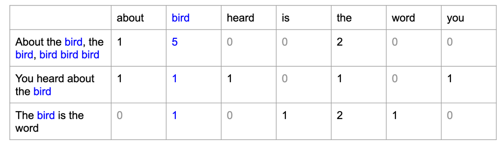

reference: [source](https://user.oc-static.com/upload/2020/10/23/16034397439042_surfin%20bird%20bow.png)

R has a function called DocumentTermMatrix which converts the documents into a Document-Term matrix. With the resulting matrix, we can find many inherent details using statistical techniques.

```r
reviews_post_dtm=DocumentTermMatrix(reviews_post)
dim(reviews_post_dtm)
```

```
## [1]  1386 31559
```

`dim` function gives the shape of an input matrix. In our case, it is `1386 x 31559`.

1386 rows - Documents

31559 columns - Words

Let’s look at a patch/subset of the matrix

```r
inspect(reviews_post_dtm[15:25,1040:1044]) # inspecting a subset of the matrix
```

```
## <<DocumentTermMatrix (documents: 11, terms: 5)>>
## Non-/sparse entries: 0/55
## Sparsity           : 100%
## Maximal term length: 16
## Weighting          : term frequency (tf)
## Sample             :
##                      Terms
## Docs                  anthrozoologists anti antiappeal antic anticharm
##   cv014_tok-12391.txt                0    0          0     0         0
##   cv015_tok-23730.txt                0    0          0     0         0
##   cv016_tok-16970.txt                0    0          0     0         0
##   cv017_tok-27221.txt                0    0          0     0         0
##   cv017_tok-29801.txt                0    0          0     0         0
##   cv018_tok-11502.txt                0    0          0     0         0
##   cv019_tok-2003.txt                 0    0          0     0         0
##   cv020_tok-13096.txt                0    0          0     0         0
##   cv021_tok-29141.txt                0    0          0     0         0
##   cv022_tok-25633.txt                0    0          0     0         0
##   cv023_tok-25625.txt                0    0          0     0         0
```

As we can see, the rows are documents and columns are words.

```r
terms_with_min_freq_15 = findFreqTerms(reviews_post_dtm,15)
youngassoc = findAssocs(reviews_post_dtm,term="young",corlimit=0.7)
reviews_post_dtm.70=removeSparseTerms(reviews_post_dtm,sparse=0.7)
reviews_post_dtm.70 # or dim(sci.rel.dtm.70)
```

```
## <<DocumentTermMatrix (documents: 1386, terms: 100)>>
## Non-/sparse entries: 63031/75569
## Sparsity           : 55%
## Maximal term length: 11
## Weighting          : term frequency (tf)
```

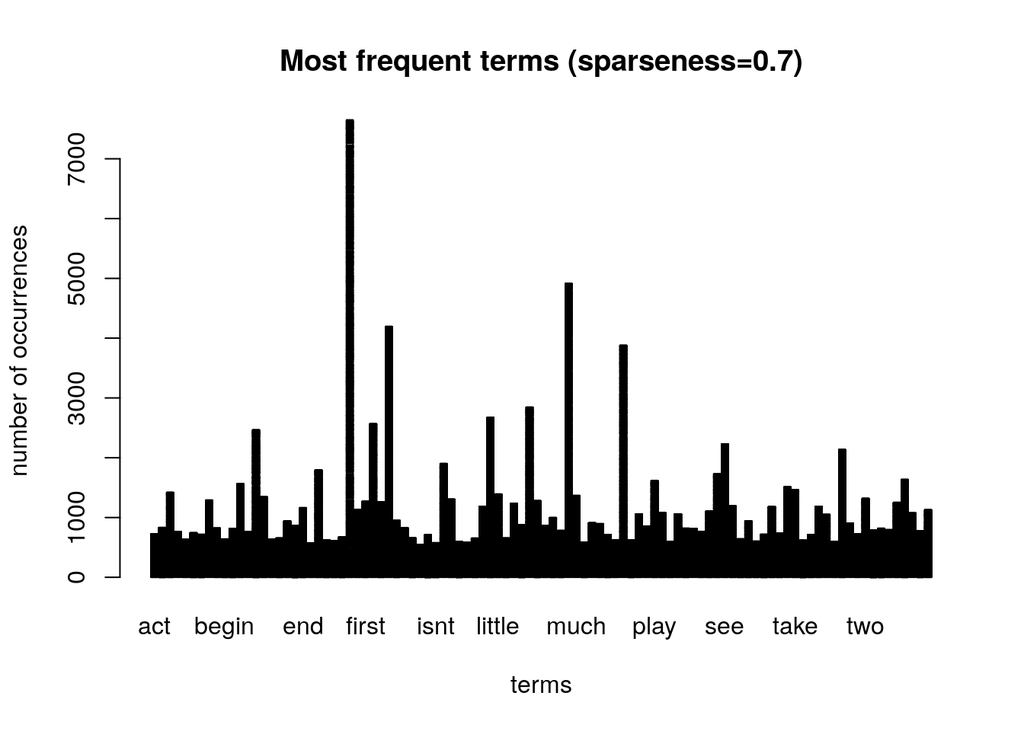

```r
# note that the term-document matrix needs to be transformed (casted)
# to a matrix form in the following barplot command
barplot(as.matrix(reviews_post_dtm.70),xlab="terms",ylab="number of occurrences",
main="Most frequent terms (sparseness=0.7)")
```

```r
reviews_post_dtm.80=removeSparseTerms(reviews_post_dtm,sparse=0.8)
reviews_post_dtm.80
```

```
## <<DocumentTermMatrix (documents: 1386, terms: 186)>>
## Non-/sparse entries: 92179/165617
## Sparsity           : 64%
## Maximal term length: 11
## Weighting          : term frequency (tf)
```

```r
reviews_post_dtm.90=removeSparseTerms(reviews_post_dtm,sparse=0.9)
reviews_post_dtm.90
```

```
## <<DocumentTermMatrix (documents: 1386, terms: 470)>>
## Non-/sparse entries: 146913/504507
## Sparsity           : 77%
## Maximal term length: 13
## Weighting          : term frequency (tf)
```

```r
reviews_post_dtm.95=removeSparseTerms(reviews_post_dtm,sparse=0.95)
reviews_post_dtm.95
```

```
## <<DocumentTermMatrix (documents: 1386, terms: 992)>>
## Non-/sparse entries: 197527/1177385
## Sparsity           : 86%
## Maximal term length: 14
## Weighting          : term frequency (tf)
```

Find words that have a correlation of a particular threshold

```r
findAssocs(reviews_post_dtm,term="love",corlimit=0.2)
```

```
## $love
##               marry         shakespeare            stoppard          apothecary
##                0.29                0.29                0.28                0.26
##  atchesonplaywright           boundless             couplet           fennymann
##                0.26                0.26                0.26                0.26
## financiallyoriented           gigliotti            henslowe              iambic
##                0.26                0.26                0.26                0.26
##            marlowes    openlyhomosexual          pentameter         rozencrantz
##                0.26                0.26                0.26                0.26
##           slimeball              wessex               firth             lesseps
##                0.26                0.26                0.24                0.24
##              madden        relationship               viola           harmonize
##                0.24                0.24                0.24                0.22
##             parfitt               dench              norman          passionate
##                0.22                0.21                0.21                0.21
##              venice        shakespeares
##                0.21                0.20
```

## 4. Visualize wordclouds for both negative & positive reviews

1. Wordcloud on Positive reviews

```r
library(wordcloud2)

# calculate the frequency of words and sort in descending order.
# Positive
wordFreqs=sort(colSums(as.matrix(reviews_post_dtm.90)[692:1386,]),decreasing=TRUE)
dataframe_4_wordcloud = data.frame("word" = names(wordFreqs), "freq" = wordFreqs)
wordcloud2(dataframe_4_wordcloud)
```

[interactive chart not shown]

2. Wordcloud on `Negative` reviews

```r
# calculate the frequency of words and sort in descending order.
# Negative
wordFreqs=sort(colSums(as.matrix(reviews_post_dtm.90)[0:692,]),decreasing=TRUE)
dataframe_4_wordcloud = data.frame("word" = names(wordFreqs), "freq" = wordFreqs)
wordcloud2(dataframe_4_wordcloud)
```

[interactive chart not shown]

There are some-rendering issues while converting to .html file. The second wordcloud was not converting properly. So, loading it like this.

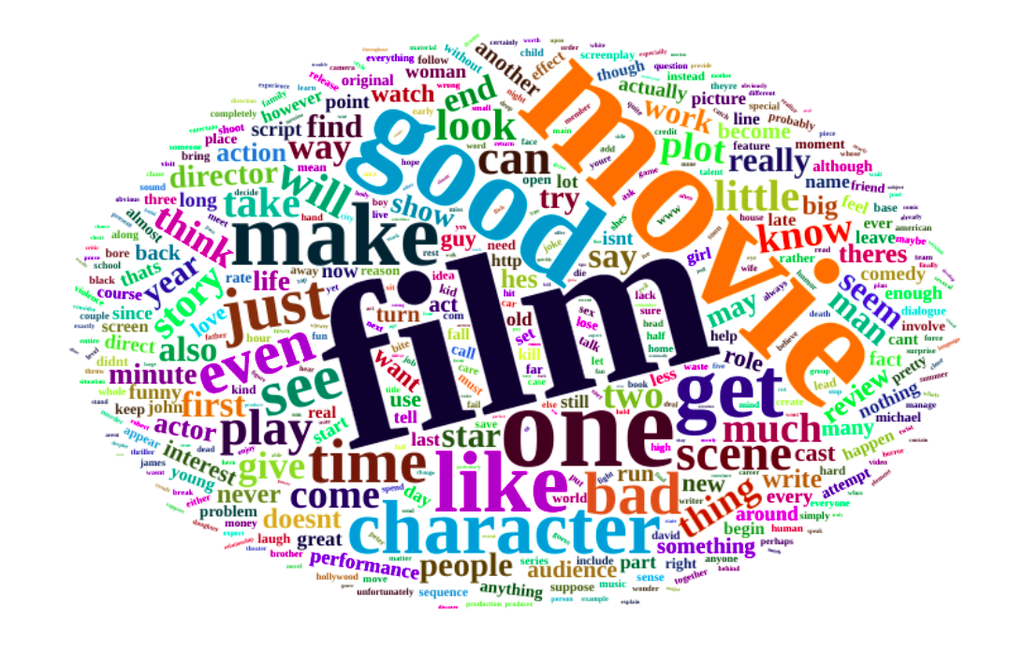

## 5. Supervised Learning Dataset creation

Since we’re making Supervised learning, we need to have labels for the data points. Add the label column and name it as `classlabeltype`. Convert the matrix into a dataframe for further ML operations.

```r
data=data.frame(as.matrix(reviews_post_dtm.90)) # convert corpus to dataFrame format
classlabeltype = c(rep("negative",692),rep("positive",694)) # create the type vector to be appended
data = cbind(data,classlabeltype)
colnames(data)[ncol(data)]="classlabeltype"
```

```r
head(data)
```

|  | able | across | act | action | actor | actually | add | age | allow | almost | along | already | also | although | always | american | another | anyone | anything | appear | arent | around | art | ask | aspect | attempt | attention | audience | away | … |
| --- | --- | --- | --- | --- | --- | --- | --- | --- | --- | --- | --- | --- | --- | --- | --- | --- | --- | --- | --- | --- | --- | --- | --- | --- | --- | --- | --- | --- | --- | --- |
| cv000_tok-9611.txt | 0 | 0 | 1 | 1 | 0 | 1 | 0 | 0 | 0 | 0 | 0 | 0 | 0 | 0 | 1 | 0 | 2 | 0 | 0 | 0 | 0 | 0 | 0 | 0 | 0 | 0 | 0 | 0 | 0 | … |
| cv001_tok-19324.txt | 0 | 0 | 0 | 1 | 0 | 0 | 1 | 0 | 0 | 0 | 0 | 0 | 1 | 0 | 0 | 5 | 1 | 0 | 0 | 1 | 0 | 2 | 0 | 0 | 0 | 0 | 0 | 1 | 0 | … |
| cv002_tok-3321.txt | 0 | 0 | 1 | 0 | 0 | 0 | 0 | 0 | 0 | 0 | 0 | 0 | 0 | 0 | 0 | 0 | 0 | 0 | 0 | 1 | 0 | 0 | 0 | 0 | 0 | 0 | 0 | 0 | 0 | … |
| cv003_tok-13044.txt | 0 | 0 | 0 | 0 | 0 | 1 | 0 | 0 | 1 | 2 | 1 | 0 | 2 | 0 | 0 | 0 | 0 | 0 | 0 | 0 | 0 | 2 | 0 | 0 | 0 | 0 | 0 | 0 | 0 | … |
| cv004_tok-25944.txt | 0 | 1 | 2 | 0 | 5 | 3 | 0 | 0 | 1 | 0 | 0 | 0 | 1 | 0 | 2 | 0 | 0 | 0 | 0 | 2 | 1 | 0 | 0 | 1 | 0 | 0 | 0 | 0 | 1 | … |
| cv005_tok-24602.txt | 0 | 0 | 1 | 0 | 0 | 1 | 0 | 0 | 0 | 1 | 0 | 1 | 2 | 0 | 0 | 0 | 0 | 0 | 0 | 1 | 0 | 0 | 0 | 0 | 0 | 0 | 1 | 0 | 1 | … |

Write the data into weka format (.arff)

```r
library(foreign)
write.arff(data,file="term-document-matrix-weka-format-for-rottentomatoes.arff")
```

## 6. Convert features (word-frequency) into numeric and label to categorical.

```r
outcomeName = 'classlabeltype'
predictors<-names(data)[!names(data) %in% outcomeName] # All features except class
# Convert all word frequency features to numeric.
data$classlabeltype =as.factor(data$classlabeltype)

data[is.na(data)] <- 0 #Replace NA with 0

for (k in predictors) {
  data[[k]] <- as.numeric(data[[k]])
}
```

## 7. Remove outliers

In the dataset, there can be a few outliers/anomalies which can, utmost, hinder the model from learning better relations b/w features. Inorder to prevent this, we find out the outliers and remove them from the corpus.

We use `IsolationForest` method from `solitude` library. IsolationForest computes an isolation score for each datapoint which will help us in identifying the outlierness.

```r
library(solitude) #Importing the library for outlier detection

iso <- isolationForest$new()
iso$fit(data[,-ncol(data)]) # Fit the dataset
```

```
## INFO  [00:20:21.449] dataset has duplicated rows
## INFO  [00:20:21.477] Building Isolation Forest ...
## INFO  [00:20:21.908] done
## INFO  [00:20:21.909] Computing depth of terminal nodes ...
## INFO  [00:20:22.207] done
## INFO  [00:20:22.257] Completed growing isolation forest
```

```r
#-ncol(data) refers to the last column i.e class column
p <- iso$predict(data[,-ncol(data)]) # Now, predict on the data to get isolation scores. Variable `p` has the isolation scores of each datapoint.
```

Now, sort the scores and plot the data

```r
sort(p$anomaly_score) #Sort the scores
```

[output not shown]

[output cut: 183 more lines]

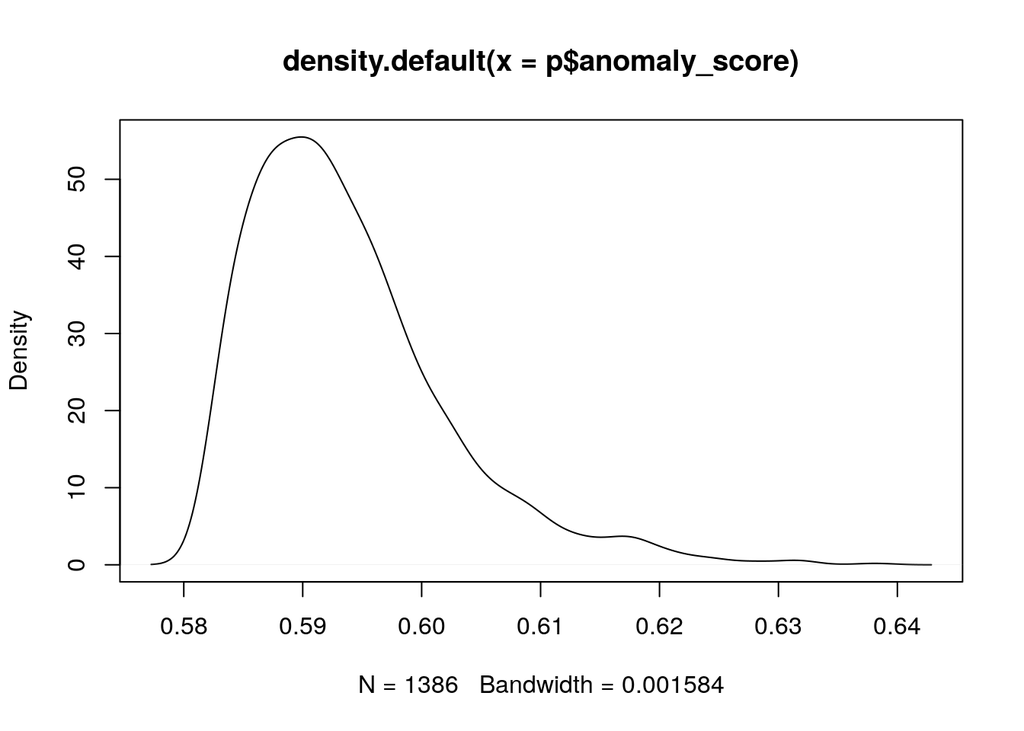

```r
plot(density(p$anomaly_score)) #Plot the data
```

From the plot, we could see that most datapoints fall under 0.58-0.61. Anything after 0.61 can be considered as outliers.

```r
outliers = (which(p$anomaly_score > 0.61))
outliers
```

```
##  [1]    5   36   40   63  124  156  171  225  239  246  258  331  337  338  346
## [16]  348  444  456  488  555  565  656  706  708  734  758  762  779  781  805
## [31]  821  834  839  866  872  873  876  912  917  955  964  974  976  977  980
## [46]  998 1019 1020 1030 1036 1044 1050 1072 1096 1105 1129 1154 1171 1182 1195
## [61] 1202 1207 1224 1231 1235 1242 1295 1296 1341
```

```r
dim(data)
```

```
## [1] 1386  471
```

Remove the outlier instances from the data

```r
data = data[-outliers,]
```

```r
dim(data)
```

```
## [1] 1317  471
```

We could see the change in dim(data). Earlier, it was 1386 x 471. Now, it is 1317 x 471. It means that certain data samples are removed.

### 7.1 Let’s see how many instances per class have been removed. Display the stats of each class in the dataset

```r
table(data["classlabeltype"])
```

```
##
## negative positive
##      670      647
```

The Class distribution after removing the outliers has changed a little

## 8. Subsampling

Earlier, both the classes had almost similar distribution i.e `negative 692 && positive 694`. But now, the difference has increased. Although this difference is not much (23 more negative instances than positive ones), let’s use R’s subsampling method to have equal number of both class instances.

We have two options i.e upsampling & downsampling. Since ML models are data-hungry, let’s upsample our data using `upSample` function.

https://topepo.github.io/caret/subsampling-for-class-imbalances.html

```r
library(caret) # Library for ML model training, hyper-parameter tuning, model comparison
data <- upSample(x = data[, -ncol(data)],
                     y = (data$classlabeltype), yname="classlabeltype")
table(data$classlabeltype)
```

```
##
## negative positive
##      670      670
```

We could see that both the classes have equal instances now

## 9. Clustering

Source: https://www.r-bloggers.com/2021/04/cluster-analysis-in-r/

```r
library(ggplot2)
library(factoextra)
```

### 9.1 Visualize using kmeans

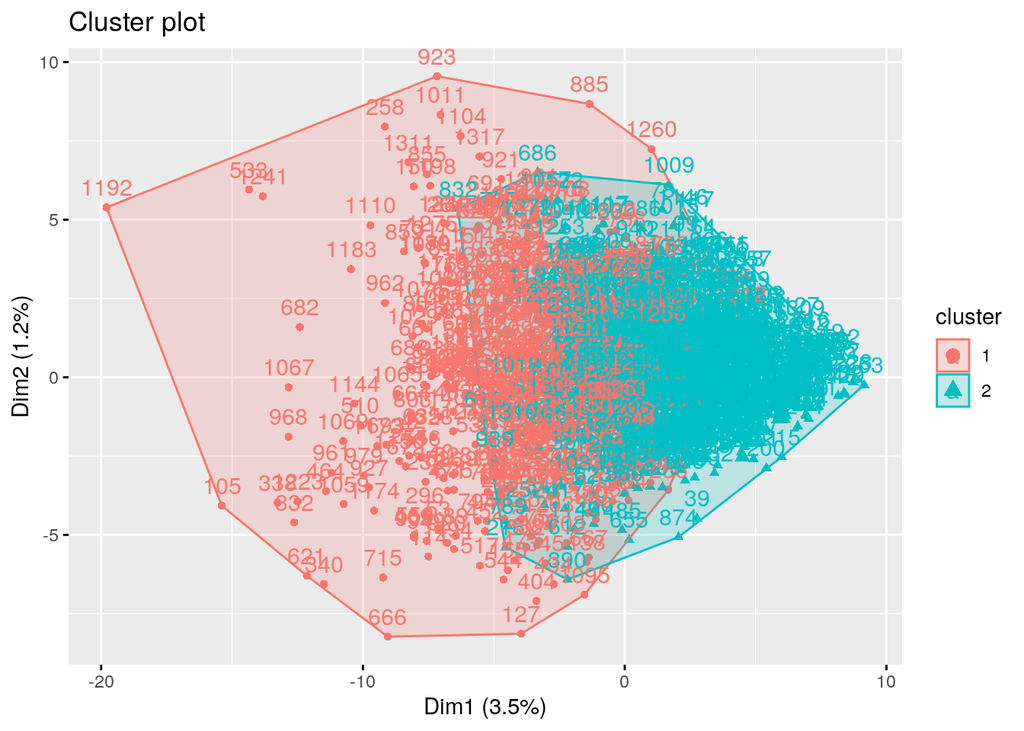

```r
km <- kmeans(data[,-ncol(data)], centers = 2, nstart = 5)

# Visualize the clusters
fviz_cluster(km, data = data[,-ncol(data)])
```

### 9.2 Average Silhouette Method

The average silhouette approach measures the quality of a clustering. It determines how well each observation lies within its cluster.

A high average silhouette width indicates a good clustering. The average silhouette method computes the average silhouette of observations for different values of k. We can execute the same based on the below code.

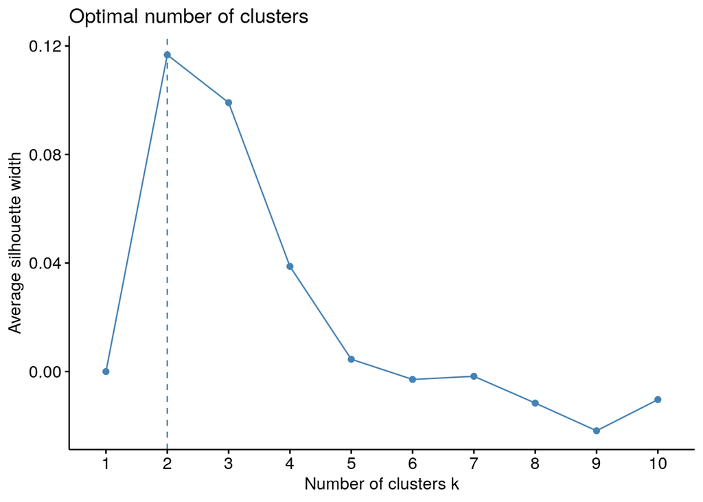

```r
fviz_nbclust(data[,-ncol(data)], kmeans, method = "silhouette")
```

We can see that the `average silhouette method` suggests 2 as the optimal number of clusters which is equal to the number of classes we have.

9.3 Hierarchical Clustering

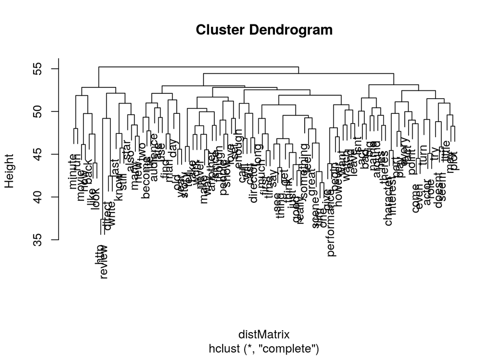

```r
distMatrix=dist(t(scale(as.matrix(reviews_post_dtm.70))))
termClustering=hclust(distMatrix,method="complete")
plot(termClustering)
```

## 10. Now, start the ML process

## Make train test splits for ML

### 10.1 Split the data

https://www.rdocumentation.org/packages/caret/versions/6.0-90/topics/createDataPartition

```r
set.seed(107) # a random seed to enable reproducibility
inTrain <- createDataPartition(y=data$classlabeltype,p=.75,list=FALSE)
```

A series of test/training partitions are created using `createDataPartition` while `createResample` creates one or more bootstrap samples. `createFolds` splits the data into k groups while `createTimeSlices` creates cross-validation split for series data. `groupKFold` splits the data based on a grouping factor.

```r
training <- data[inTrain,]
testing <- data[-inTrain,]
nrow(training)
```

```
## [1] 1006
```

```r
head(training)
```

|  | able | across | act | action | actor | actually | add | age | allow | almost | along | already | also | although | always | american | another | anyone | anything | appear | arent | around | art | ask | aspect | attempt | attention | audience | away | … |
| --- | --- | --- | --- | --- | --- | --- | --- | --- | --- | --- | --- | --- | --- | --- | --- | --- | --- | --- | --- | --- | --- | --- | --- | --- | --- | --- | --- | --- | --- | --- |
| 1 | 0 | 0 | 1 | 1 | 0 | 1 | 0 | 0 | 0 | 0 | 0 | 0 | 0 | 0 | 1 | 0 | 2 | 0 | 0 | 0 | 0 | 0 | 0 | 0 | 0 | 0 | 0 | 0 | 0 | … |
| 2 | 0 | 0 | 0 | 1 | 0 | 0 | 1 | 0 | 0 | 0 | 0 | 0 | 1 | 0 | 0 | 5 | 1 | 0 | 0 | 1 | 0 | 2 | 0 | 0 | 0 | 0 | 0 | 1 | 0 | … |
| 3 | 0 | 0 | 1 | 0 | 0 | 0 | 0 | 0 | 0 | 0 | 0 | 0 | 0 | 0 | 0 | 0 | 0 | 0 | 0 | 1 | 0 | 0 | 0 | 0 | 0 | 0 | 0 | 0 | 0 | … |
| 7 | 0 | 0 | 0 | 0 | 1 | 1 | 0 | 0 | 0 | 0 | 0 | 0 | 0 | 0 | 0 | 0 | 0 | 0 | 0 | 1 | 1 | 1 | 0 | 1 | 0 | 1 | 0 | 3 | 0 | … |
| 8 | 0 | 0 | 0 | 1 | 0 | 1 | 0 | 0 | 0 | 0 | 0 | 0 | 1 | 0 | 0 | 0 | 1 | 1 | 0 | 1 | 0 | 0 | 0 | 0 | 0 | 0 | 0 | 0 | 0 | … |
| 9 | 0 | 0 | 1 | 1 | 0 | 1 | 1 | 0 | 0 | 0 | 0 | 0 | 0 | 0 | 1 | 0 | 1 | 0 | 0 | 0 | 0 | 0 | 0 | 0 | 1 | 0 | 0 | 1 | 1 | … |

## 11. Consult model names

```r
modelnames <- paste(names(getModelInfo()), collapse=',')
modelnames
```

```
## [1] "ada,AdaBag,AdaBoost.M1,adaboost,amdai,ANFIS,avNNet,awnb,awtan,bag,bagEarth,bagEarthGCV,bagFDA,bagFDAGCV,bam,bartMachine,bayesglm,binda,blackboost,blasso,blassoAveraged,bridge,brnn,BstLm,bstSm,bstTree,C5.0,C5.0Cost,C5.0Rules,C5.0Tree,cforest,chaid,CSimca,ctree,ctree2,cubist,dda,deepboost,DENF…
```

## 12. Model-1: Training & tuning

As a first model, we use Neural Networks `nnet`. Neural networks are preferred because of their non-linear activation functions. This non-linearity is useful in approximating the non-linear datasets. Specifically, we fit a single-hidden-layer neural network. As of now, we don’t use skip-connections. The possible parameters of this method are

```
weights => (case) weights for each example -- if missing defaults to 1. We don't disturb it. we weight all of the parameters equally.
size => number of units in the hidden layer. Can be zero if there are skip-layer units.
Wts => initial parameter vector. If missing chosen at random.
mask => logical vector indicating which parameters should be optimized (default all).
linout => switch for linear output units. Default logistic output units.
entropy => switch for entropy (= maximum conditional likelihood) fitting. Default by least-squares.
softmax => switch for softmax (log-linear model) and maximum conditional likelihood fitting. linout, entropy, softmax and censored are mutually exclusive.
censored => A variant on softmax, in which non-zero targets mean possible classes. Thus for softmax a row of (0, 1, 1) means one example each of classes 2 and 3, but for censored it means one example whose class is only known to be 2 or 3. skip switch to add skip-layer connections from input to output. rang Initial random weights on [-rang, rang]. Value about 0.5 unless the inputs are large, in which case it should be chosen so that rang * max(|x|) is about 1. decay parameter for weight decay. Default 0. maxit maximum number of iterations. Default 100. Hess If true, the Hessian of the measure of fit at the best set of weights found is returned as component Hessian. trace switch for tracing optimization. Default TRUE.

MaxNWts => The maximum allowable number of weights. There is no intrinsic limit in the code, but increasing MaxNWts will probably allow fits that are very slow and time-consuming.
abstol => Stop if the fit criterion falls below abstol, indicating an essentially perfect fit.
reltol => Stop if the optimizer is unable to reduce the fit criterion by a factor of at least 1 - reltol.
```

### 12.1 Fix the training params

```r
# fixing the performance estimation procedure
ctrl <- trainControl(method = "repeatedcv",repeats=3, number=10)
```

The arguments of this function are

```
method => The resampling method: "boot", "boot632", "optimism_boot", "boot_all", "cv", "repeatedcv", "LOOCV", "LGOCV" (for repeated training/test splits), "none" (only fits one model to the entire training set), "oob" (only for random forest, bagged trees, bagged earth, bagged flexible discriminant analysis, or conditional tree forest models), timeslice, "adaptive_cv", "adaptive_boot" or "adaptive_LGOCV"

number => Either the number of folds or number of resampling iterations
repeats => For repeated k-fold cross-validation only: the number of complete sets of folds to compute
p => For leave-group out cross-validation: the training percentage
search  => Either "grid" or "random", describing how the tuning parameter grid is determined. See details below.
verboseIter => A logical for printing a training log.
returnData  => A logical for saving the data
returnResamp => A character string indicating how much of the resampled summary metrics should be saved. Values can be "final", "all" or "none"
savePredictions => an indicator of how much of the hold-out predictions for each resample should be saved. Values can be either "all", "final", or "none". A logical value can also be used that convert to "all" (for true) or "none" (for false). "final" saves the predictions for the optimal tuning parameters.
classProbs => a logical; should class probabilities be computed for classification models (along with predicted values) in each resample?
summaryFunction => a function to compute performance metrics across resamples. The arguments to the function should be the same as those in defaultSummary. Note that if method = "oob" is used, this option is ignored and a warning is issued.
selectionFunction   => the function used to select the optimal tuning parameter. This can be a name of the function or the function itself. See best for details and other options.
preProcOptions  => A list of options to pass to preProcess. The type of pre-processing (e.g. center, scaling etc) is passed in via the preProc option in train.
sampling    => a single character value describing the type of additional sampling that is conducted after resampling (usually to resolve class imbalances). Values are "none", "down", "up", "smote", or "rose". The latter two values require the themis and ROSE packages, respectively. This argument can also be a list to facilitate custom sampling and these details can be found on the caret package website for sampling (link below).
index   => a list with elements for each resampling iteration. Each list element is a vector of integers corresponding to the rows used for training at that iteration.
indexOut    => a list (the same length as index) that dictates which data are held-out for each resample (as integers). If NULL, then the unique set of samples not contained in index is used.
indexFinal  => an optional vector of integers indicating which samples are used to fit the final model after resampling. If NULL, then entire data set is used.
timingSamps => the number of training set samples that will be used to measure the time for predicting samples (zero indicates that the prediction time should not be estimated.
predictionBounds    => a logical or numeric vector of length 2 (regression only). If logical, the predictions can be constrained to be within the limit of the training set outcomes. For example, a value of c(TRUE, FALSE) would only constrain the lower end of predictions. If numeric, specific bounds can be used. For example, if c(10, NA), values below 10 would be predicted as 10 (with no constraint in the upper side).
seeds   => an optional set of integers that will be used to set the seed at each resampling iteration. This is useful when the models are run in parallel. A value of NA will stop the seed from being set within the worker processes while a value of NULL will set the seeds using a random set of integers. Alternatively, a list can be used. The list should have B+1 elements where B is the number of resamples, unless method is "boot632" in which case B is the number of resamples plus 1. The first B elements of the list should be vectors of integers of length M where M is the number of models being evaluated. The last element of the list only needs to be a single integer (for the final model). See the Examples section below and the Details section.
adaptive    => a list used when method is "adaptive_cv", "adaptive_boot" or "adaptive_LGOCV". See Details below.
```

```r
options(warn=-1)

model_nnet<-train(training[,predictors],training[,outcomeName],method='nnet', trControl=ctrl,tuneLength=3, maxit=300,
                 metric='Accuracy')
model_nnet
```

```
## Neural Network
##
## 1006 samples
##  470 predictor
##    2 classes: 'negative', 'positive'
##
## No pre-processing
## Resampling: Cross-Validated (10 fold, repeated 3 times)
## Summary of sample sizes: 906, 905, 905, 905, 906, 905, ...
## Resampling results across tuning parameters:
##
##   size  decay  Accuracy   Kappa
##   1     0e+00  0.6988365  0.3974537
##   1     1e-04  0.7120248  0.4241541
##   1     1e-01  0.7452361  0.4905912
##   3     0e+00        NaN        NaN
##   3     1e-04        NaN        NaN
##   3     1e-01        NaN        NaN
##   5     0e+00        NaN        NaN
##   5     1e-04        NaN        NaN
##   5     1e-01        NaN        NaN
##
## Accuracy was used to select the optimal model using the largest value.
## The final values used for the model were size = 1 and decay = 0.1.
```

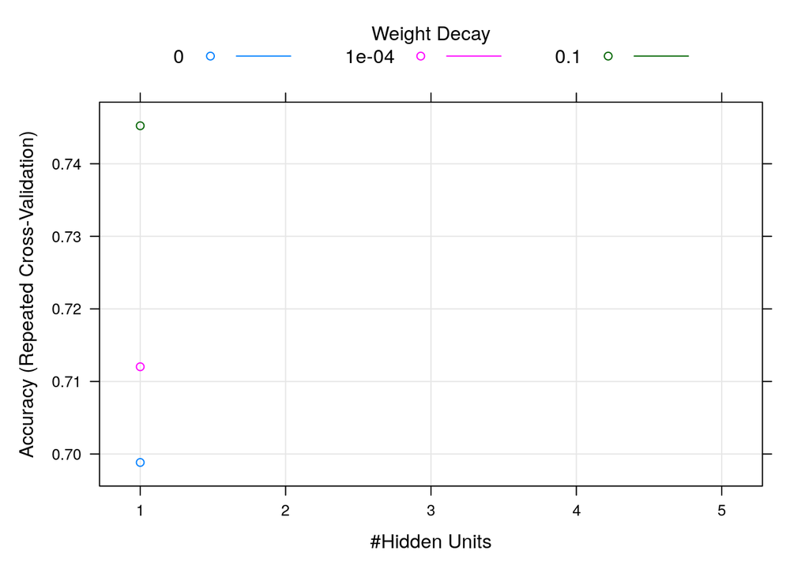

```r
plot(model_nnet)
```

## 13. Model-2: Training & tuning

As a second model, we choose XGBoost. Specifically, we choose a variant of it called `xgbLinear` because of the speed constraints.

More about boosting & xgboost: Boosting is an ensemble technique where new models are added to correct the errors made by existing models. Models are added sequentially until no further improvements can be made. A popular example is the AdaBoost algorithm that weights data points that are hard to predict.

Gradient boosting is an approach where new models are created that predict the residuals or errors of prior models and then added together to make the final prediction. It is called gradient boosting because it uses a gradient descent algorithm to minimize the loss when adding new models.

```r
options(warn=-1)

ctrl <- trainControl(method = "repeatedcv",repeats=3)
model_xgb<-train(training[,predictors],training[,outcomeName],method='xgbLinear',
                 trControl=ctrl,tuneLength=3,
                 metric="Accuracy")
```

```r
model_xgb
```

```
## eXtreme Gradient Boosting
##
## 1006 samples
##  470 predictor
##    2 classes: 'negative', 'positive'
##
## No pre-processing
## Resampling: Cross-Validated (10 fold, repeated 3 times)
## Summary of sample sizes: 905, 906, 905, 905, 905, 906, ...
## Resampling results across tuning parameters:
##
##   lambda  alpha  nrounds  Accuracy   Kappa
##   0e+00   0e+00   50      0.7381981  0.4762981
##   0e+00   0e+00  100      0.7431290  0.4861996
##   0e+00   0e+00  150      0.7480962  0.4961335
##   0e+00   1e-04   50      0.7375311  0.4750479
##   0e+00   1e-04  100      0.7454620  0.4908815
##   0e+00   1e-04  150      0.7464556  0.4928713
##   0e+00   1e-01   50      0.7286002  0.4572190
##   0e+00   1e-01  100      0.7371816  0.4743175
##   0e+00   1e-01  150      0.7381782  0.4763222
##   1e-04   0e+00   50      0.7375017  0.4749934
##   1e-04   0e+00  100      0.7434523  0.4868719
##   1e-04   0e+00  150      0.7480698  0.4961117
##   1e-04   1e-04   50      0.7371879  0.4743336
##   1e-04   1e-04  100      0.7471415  0.4942499
##   1e-04   1e-04  150      0.7448281  0.4895967
##   1e-04   1e-01   50      0.7288943  0.4578073
##   1e-04   1e-01  100      0.7355084  0.4709697
##   1e-04   1e-01  150      0.7418054  0.4835984
##   1e-01   0e+00   50      0.7378549  0.4757056
##   1e-01   0e+00  100      0.7484816  0.4969173
##   1e-01   0e+00  150      0.7537758  0.5075096
##   1e-01   1e-04   50      0.7335281  0.4670585
##   1e-01   1e-04  100      0.7517657  0.5035148
##   1e-01   1e-04  150      0.7524326  0.5048097
##   1e-01   1e-01   50      0.7315935  0.4631249
##   1e-01   1e-01  100      0.7421483  0.4842721
##   1e-01   1e-01  150      0.7424884  0.4849394
##
## Tuning parameter 'eta' was held constant at a value of 0.3
## Accuracy was used to select the optimal model using the largest value.
## The final values used for the model were nrounds = 150, lambda = 0.1, alpha =
##  0 and eta = 0.3.
```

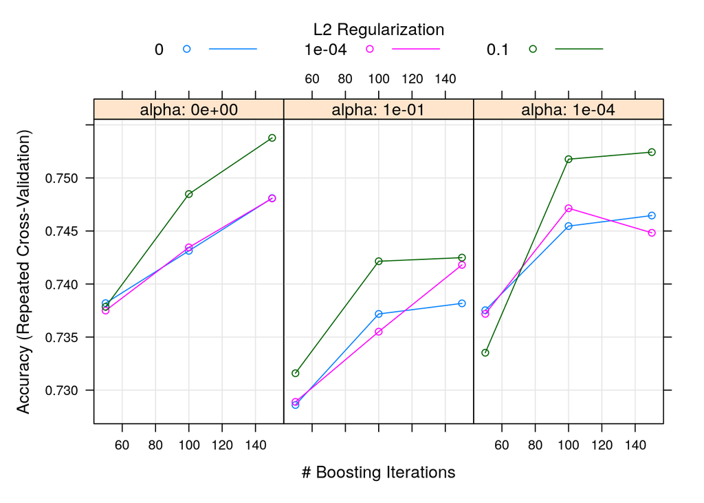

```r
plot(model_xgb)
```

### 13.1 Plot feature importance of xgb model

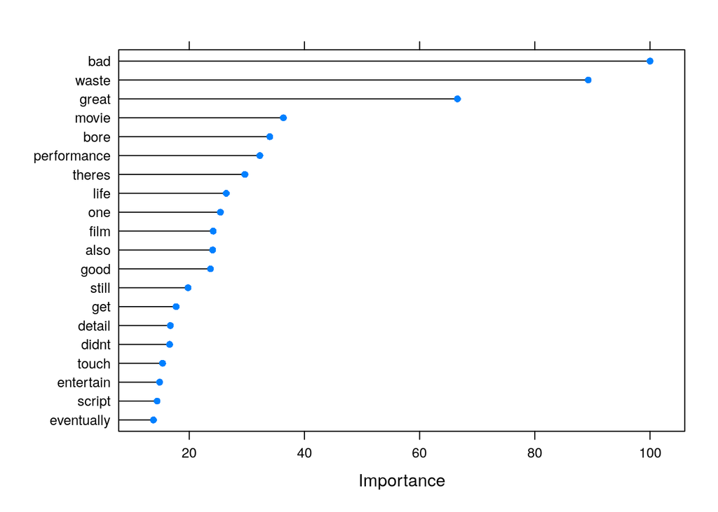

```r
importance = varImp(object=model_xgb)
plot(importance, top=20)
```

### 13.2 Plot feature importance of nnet model

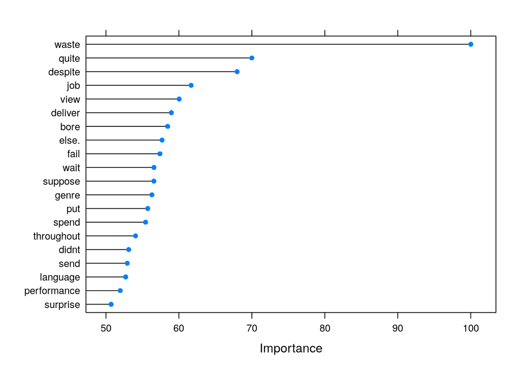

```r
importance = varImp(object=model_nnet)
plot(importance, top=20)
```

## 14. Feature selection

Source: https://topepo.github.io/caret/recursive-feature-elimination.html

```r
# Number of features to consider. The model will consider given number of features & check the score against it.
subsets <- c(50, 75, 150, 200)
```

The simulation will fit models with subset sizes of 50, 75, 150, 200

`lrFuncs` for logistic regression. `rfFuncs` for random Forest

We use fit linear models, the `lrFuncs` set of functions can be used. To do this, a control object is created with the rfeControl function. We also specify that repeated 10-fold cross-validation should be used in line 2.1 of Algorithm 2. The number of folds can be changed via the number argument to rfeControl (defaults to 10). The verbose option prevents copious amounts of output from being produced.

https://stackoverflow.com/questions/42984651/how-r-recursive-feature-elimination-with-logistic-regression

```r
# Feature selection
ctrl <- rfeControl(functions = lrFuncs,
                   method = "repeatedcv",
                   repeats = 3,
                   verbose = FALSE)

lmProfile <- rfe(training[,predictors], training[,outcomeName],
                 sizes = subsets,
                 rfeControl = ctrl)
```

See the results

```r
lmProfile
```

```
##
## Recursive feature selection
##
## Outer resampling method: Cross-Validated (10 fold, repeated 3 times)
##
## Resampling performance over subset size:
##
##  Variables Accuracy  Kappa AccuracySD KappaSD Selected
##         50   0.6882 0.3763    0.05029 0.10064
##         75   0.7100 0.4201    0.04201 0.08401        *
##        150   0.7042 0.4084    0.05292 0.10584
##        200   0.7032 0.4063    0.04701 0.09403
##        470   0.6845 0.3691    0.05299 0.10584
##
## The top 5 variables (out of 75):
##    waste, great, didnt, deliver, performance
```

https://www.analyticsvidhya.com/blog/2016/12/introduction-to-feature-selection-methods-with-an-example-or-how-to-select-the-right-variables/

## 15. Feature Extraction

For PCA, we can look at all the following links,

http://www.sthda.com/english/articles/31-principal-component-methods-in-r-practical-guide/118-principal-component-analysis-in-r-prcomp-vs-princomp/

https://cmdlinetips.com/2019/04/introduction-to-pca-with-r-using-prcomp/

https://rstudio-pubs-static.s3.amazonaws.com/92006_344e916f251146daa0dc49fef94e2104.html

```r
pca_res <- prcomp(training[,predictors])
summary(pca_res)
```

```
## Importance of components:
##                            PC1     PC2     PC3     PC4    PC5     PC6     PC7
## Standard deviation     5.02965 3.82066 2.51668 2.14304 2.0519 1.96512 1.90512
## Proportion of Variance 0.09737 0.05618 0.02438 0.01768 0.0162 0.01486 0.01397
## Cumulative Proportion  0.09737 0.15355 0.17793 0.19560 0.2118 0.22667 0.24064
##                            PC8     PC9    PC10    PC11    PC12    PC13    PC14
## Standard deviation     1.79990 1.69958 1.66581 1.60280 1.58910 1.56867 1.53954
## Proportion of Variance 0.01247 0.01112 0.01068 0.00989 0.00972 0.00947 0.00912
## Cumulative Proportion  0.25311 0.26423 0.27491 0.28480 0.29452 0.30399 0.31311
##                           PC15    PC16    PC17   PC18    PC19    PC20    PC21
## Standard deviation     1.52842 1.51143 1.47007 1.4415 1.40883 1.40172 1.38550
## Proportion of Variance 0.00899 0.00879 0.00832 0.0080 0.00764 0.00756 0.00739
## Cumulative Proportion  0.32210 0.33089 0.33921 0.3472 0.35485 0.36241 0.36980
##                           PC22   PC23    PC24    PC25   PC26    PC27   PC28
## Standard deviation     1.37437 1.3484 1.34400 1.33009 1.3097 1.29040 1.2688
## Proportion of Variance 0.00727 0.0070 0.00695 0.00681 0.0066 0.00641 0.0062
## Cumulative Proportion  0.37707 0.3841 0.39102 0.39783 0.4044 0.41084 0.4170
##                           PC29    PC30    PC31    PC32    PC33    PC34    PC35
## Standard deviation     1.25700 1.24950 1.24423 1.23882 1.22586 1.21784 1.20107
## Proportion of Variance 0.00608 0.00601 0.00596 0.00591 0.00578 0.00571 0.00555
## Cumulative Proportion  0.42312 0.42912 0.43508 0.44099 0.44677 0.45248 0.45803
##                           PC36    PC37   PC38    PC39    PC40    PC41    PC42
## Standard deviation     1.19628 1.18633 1.1840 1.16162 1.13645 1.13256 1.12320
## Proportion of Variance 0.00551 0.00542 0.0054 0.00519 0.00497 0.00494 0.00486
## Cumulative Proportion  0.46354 0.46896 0.4744 0.47955 0.48452 0.48946 0.49431
##                           PC43    PC44    PC45    PC46    PC47    PC48    PC49
## Standard deviation     1.11781 1.10144 1.09776 1.09022 1.08836 1.07930 1.07600
## Proportion of Variance 0.00481 0.00467 0.00464 0.00457 0.00456 0.00448 0.00446
## Cumulative Proportion  0.49912 0.50379 0.50843 0.51300 0.51756 0.52205 0.52650
##                           PC50    PC51    PC52    PC53    PC54    PC55    PC56
## Standard deviation     1.06429 1.06094 1.05582 1.04693 1.03978 1.03376 1.02342
## Proportion of Variance 0.00436 0.00433 0.00429 0.00422 0.00416 0.00411 0.00403
## Cumulative Proportion  0.53086 0.53519 0.53949 0.54370 0.54786 0.55198 0.55601
##                           PC57    PC58    PC59   PC60    PC61    PC62    PC63
## Standard deviation     1.02130 1.01630 1.00949 1.0069 0.99873 0.99140 0.98290
## Proportion of Variance 0.00401 0.00398 0.00392 0.0039 0.00384 0.00378 0.00372
## Cumulative Proportion  0.56002 0.56400 0.56792 0.5718 0.57566 0.57945 0.58316
##                           PC64    PC65    PC66    PC67    PC68    PC69    PC70
## Standard deviation     0.97343 0.96643 0.96071 0.95115 0.94867 0.94473 0.94182
## Proportion of Variance 0.00365 0.00359 0.00355 0.00348 0.00346 0.00344 0.00341
```

[output cut: 218 more lines]

```
## Standard deviation     0.18050 0.17911 0.17872 0.17688 0.17465 0.17401 0.17237
## Proportion of Variance 0.00013 0.00012 0.00012 0.00012 0.00012 0.00012 0.00011
## Cumulative Proportion  0.99786 0.99799 0.99811 0.99823 0.99835 0.99846 0.99858
##                          PC456   PC457   PC458  PC459  PC460  PC461  PC462
## Standard deviation     0.16868 0.16775 0.16573 0.1651 0.1640 0.1606 0.1598
## Proportion of Variance 0.00011 0.00011 0.00011 0.0001 0.0001 0.0001 0.0001
## Cumulative Proportion  0.99869 0.99880 0.99890 0.9990 0.9991 0.9992 0.9993
##                         PC463   PC464   PC465   PC466   PC467   PC468   PC469
## Standard deviation     0.1577 0.15672 0.15376 0.15030 0.14935 0.14786 0.14569
## Proportion of Variance 0.0001 0.00009 0.00009 0.00009 0.00009 0.00008 0.00008
## Cumulative Proportion  0.9994 0.99950 0.99959 0.99968 0.99976 0.99985 0.99993
##                          PC470
## Standard deviation     0.13603
## Proportion of Variance 0.00007
## Cumulative Proportion  1.00000
```

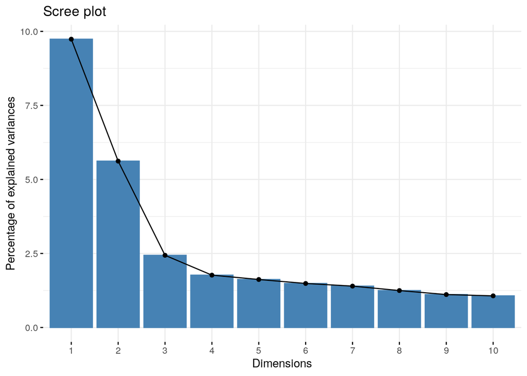

```r
fviz_eig(pca_res, )
```

Maximum variance explained by the principal component is 10%, which is quite low. This doesn’t mean being PCA good or bad. The values we have, where two principal components do not explain a big part of variance, mean that the data is far from being near a 2 dimensional subspace. It can be inferred that the current data has many dimensions, as the variance of the second component only explains 5% and rest of components must explain even less.

Find more on why this happens here -> https://stats.stackexchange.com/a/464203

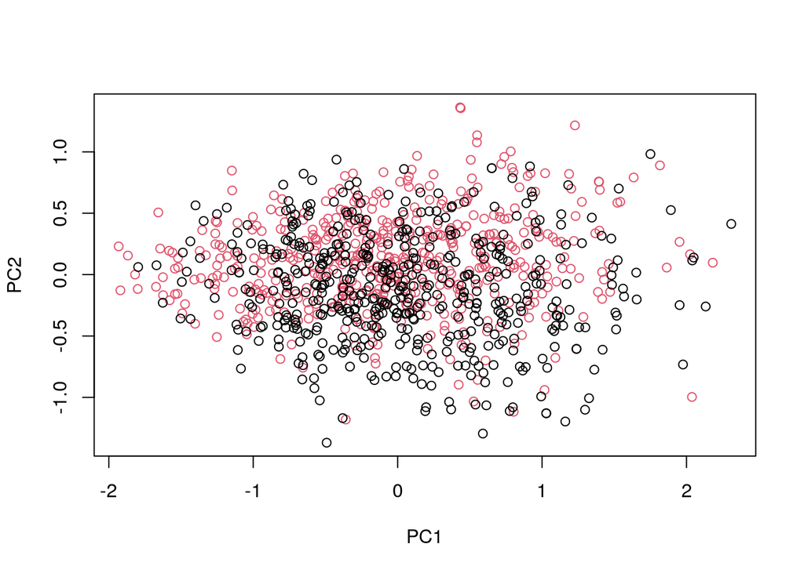

```r
typeColor <- ((training$classlabeltype=="negative")*1 + 1)
prComp <- prcomp(log10(training[,predictors]+1))
plot(prComp$x[,1],prComp$x[,2],col=typeColor,xlab="PC1",ylab="PC2")
```

By plotting the two principal dimensions, we could notice that there is no clear demarcation between negative and positive classes across the principal dimensions 1,2.

## 16. Predictions

### 16.1 Predictions using XGB model and confusion matrix calculation

```r
predictions<-predict.train(object=model_xgb,testing[,predictors],type="raw")
confusionMatrix(predictions,testing[,outcomeName])
```

```
## Confusion Matrix and Statistics
##
##           Reference
## Prediction negative positive
##   negative      128       46
##   positive       39      121
##
##                Accuracy : 0.7455
##                  95% CI : (0.6952, 0.7914)
##     No Information Rate : 0.5
##     P-Value [Acc > NIR] : <2e-16
##
##                   Kappa : 0.491
##
##  Mcnemar's Test P-Value : 0.5152
##
##             Sensitivity : 0.7665
##             Specificity : 0.7246
##          Pos Pred Value : 0.7356
##          Neg Pred Value : 0.7563
##              Prevalence : 0.5000
##          Detection Rate : 0.3832
##    Detection Prevalence : 0.5210
##       Balanced Accuracy : 0.7455
##
##        'Positive' Class : negative
##
```

### 16.2 Apart from the above shown way, one can also predict in a different way

```r
x = subset(testing, select = -classlabeltype)
xgbModelClasses <- predict(model_xgb, newdata = x)
confusionMatrix(data=xgbModelClasses,testing$classlabeltype)
```

```
## Confusion Matrix and Statistics
##
##           Reference
## Prediction negative positive
##   negative      128       46
##   positive       39      121
##
##                Accuracy : 0.7455
##                  95% CI : (0.6952, 0.7914)
##     No Information Rate : 0.5
##     P-Value [Acc > NIR] : <2e-16
##
##                   Kappa : 0.491
##
##  Mcnemar's Test P-Value : 0.5152
##
##             Sensitivity : 0.7665
##             Specificity : 0.7246
##          Pos Pred Value : 0.7356
##          Neg Pred Value : 0.7563
##              Prevalence : 0.5000
##          Detection Rate : 0.3832
##    Detection Prevalence : 0.5210
##       Balanced Accuracy : 0.7455
##
##        'Positive' Class : negative
##
```

### 16.3 Predictions using NNET model and confusion matrix calculation

```r
predictions<-predict.train(object=model_nnet,testing[,predictors],type="raw")
confusionMatrix(predictions,testing[,outcomeName])
```

```
## Confusion Matrix and Statistics
##
##           Reference
## Prediction negative positive
##   negative      121       45
##   positive       46      122
##
##                Accuracy : 0.7275
##                  95% CI : (0.6764, 0.7746)
##     No Information Rate : 0.5
##     P-Value [Acc > NIR] : <2e-16
##
##                   Kappa : 0.4551
##
##  Mcnemar's Test P-Value : 1
##
##             Sensitivity : 0.7246
##             Specificity : 0.7305
##          Pos Pred Value : 0.7289
##          Neg Pred Value : 0.7262
##              Prevalence : 0.5000
##          Detection Rate : 0.3623
##    Detection Prevalence : 0.4970
##       Balanced Accuracy : 0.7275
##
##        'Positive' Class : negative
##
```

## 17 Statistical comparison between your pair of selected classifiers

Now, we check which of the two classifiers is the best. For that, we get all the re-samples -> 30 from 3 (repeats of) x 10 (10-fold cross-validation process). For each of these 30 samples, we check the performance of the classifiers.

```r
resamps=resamples(list(xgbTree=model_xgb,nnet=model_nnet),)
summary(resamps)
```

```
##
## Call:
## summary.resamples(object = resamps)
##
## Models: xgbTree, nnet
## Number of resamples: 30
##
## Accuracy
##              Min.   1st Qu.    Median      Mean   3rd Qu. Max. NA's
## xgbTree 0.6831683 0.7326733 0.7562376 0.7537758 0.7791337 0.83    0
## nnet    0.6700000 0.7206931 0.7376471 0.7452361 0.7780693 0.82    0
##
## Kappa
##              Min.   1st Qu.    Median      Mean   3rd Qu. Max. NA's
## xgbTree 0.3655281 0.4648215 0.5124995 0.5075096 0.5579788 0.66    0
## nnet    0.3400000 0.4414269 0.4752941 0.4905912 0.5561051 0.64    0
```

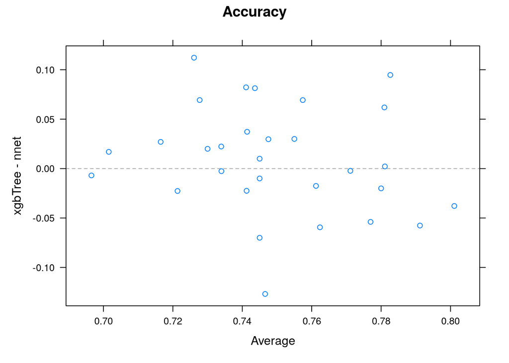

```r
xyplot(resamps,what="BlandAltman")
```

The resulting plot has a lot of details to infer. Each dot refers to a resample. So, there are 30 dots (30 resamples).

Average accuracy is around `74` & max accuracy is around `80`. Out of these 30 resamples, `xgb` performs better on `16 resamples` (look at the y-column `xgb - nnet`. Positive values mean `xgb` has better score than `nnet`) and `nnet` on the `remaining 14 resamples`. This suggests that models are comparatively similar in performance. But to know if they’re actually similar, we need to perform a t-test to get the p-value. We use `diff` function to calculate the p-value which will be used in analyzing the significance of the differences between compared classifiers. In its current implementation, `caret` applies a t-test to obtain the significance of the differences between the pair of compared classifiers.

We pass the resampled object results into `diff` for p-value calculation. We use summary

```r
diffs<-diff(resamps)
summary(diffs)
```

```
##
## Call:
## summary.diff.resamples(object = diffs)
##
## p-value adjustment: bonferroni
## Upper diagonal: estimates of the difference
## Lower diagonal: p-value for H0: difference = 0
##
## Accuracy
##         xgbTree nnet
## xgbTree         0.00854
## nnet    0.3959
##
## Kappa
##         xgbTree nnet
## xgbTree         0.01692
## nnet    0.4008
```

We can also use Dotplot. It is also used to look at the mean of difference of two models’ scores

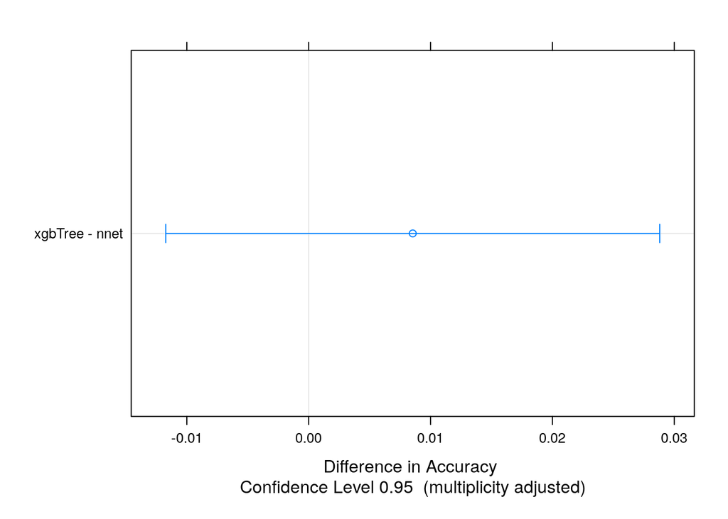

```r
# dot plots of results
dotplot(diffs)
```

We can also use `compare_models` to verify the observations obtained from `diff`. Source: https://cran.r-project.org/web/packages/caret/caret.pdf

```r
compare_models(model_xgb, model_nnet)
```

```
##
##  One Sample t-test
##
## data:  x
## t = 0.86182, df = 29, p-value = 0.3959
## alternative hypothesis: true mean is not equal to 0
## 95 percent confidence interval:
##  -0.01172615  0.02880542
## sample estimates:
##   mean of x
## 0.008539636
```

As per `compare_models` & diff function, Since the p-value is high (0.39) > 0.05, we can say that we have no evidence against the Null hypothesis (that they’re similar). If the p-value is larger than 0.05, we cannot conclude that a significant difference exists.